# IODS course project

Next I will draw a boxplot of the mean weight of the rats during the study. First I will calculate the mean wegiht in the different groups.

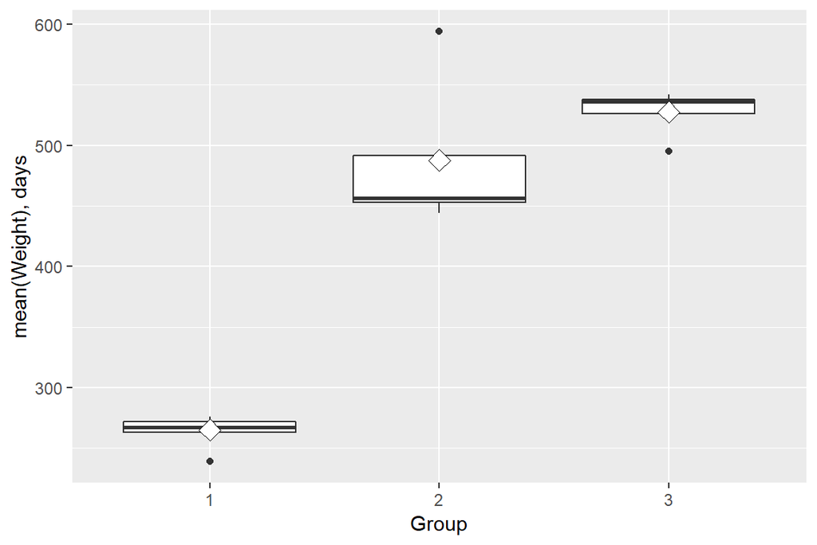

```r
#creating a summary data by Group and IDwith the mean as the summary variable
RATSLT <- RATSL %>%
  filter(Time > 1) %>%
  group_by(Group, ID) %>%
  summarise( mean=mean(Weight) ) %>%
  ungroup()

#drawing a boxplot of mean vs Group
ggplot(RATSLT, aes(x = Group, y = mean)) +
  geom_boxplot() +
  stat_summary(fun.y = "mean", geom = "point", shape=23, size=4, fill = "white") +
  scale_y_continuous(name = "mean(Weight), days")
```

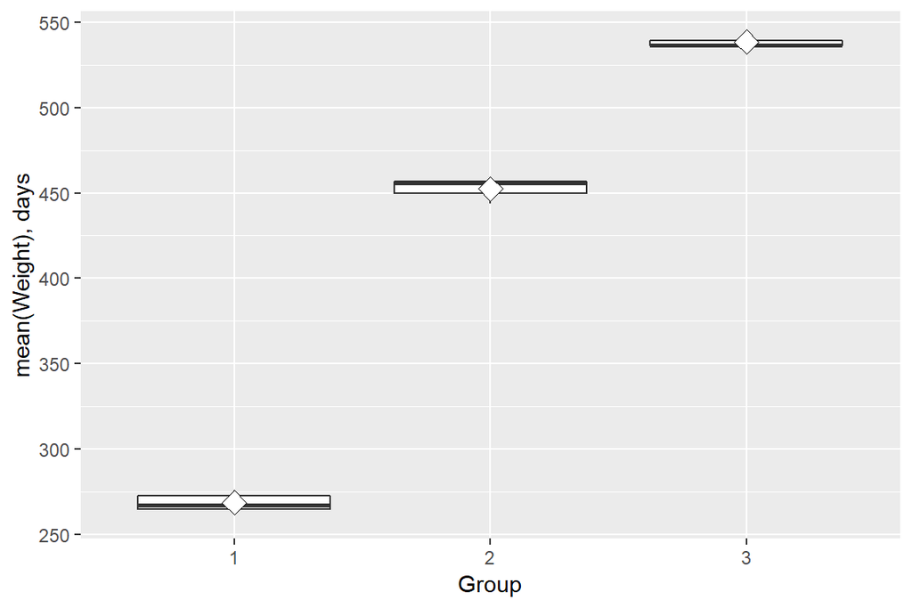

```r
RATSLT1 <- filter(RATSLT, (Group ==1 & mean >250) |(Group == 2 & mean < 550) | (Group == 3 & mean >500))
ggplot(RATSLT1, aes(x = Group, y = mean)) +
  geom_boxplot() +
  stat_summary(fun.y = "mean", geom = "point", shape=23, size=4, fill = "white") +
  scale_y_continuous(name = "mean(Weight), days")
```

After removing the outlie, the variance in the mean is much lower. This mean that the outlier affected the mean of the group more than the rest of the rats affect it. For example in group two where the largest change could be seen, the rest of the rats seem to be in the almost same weight, while the outlier was drastically above that weight (the outlier’s weight is approximately 600g and the rest of the rats’meanweight is around 450g). Since the outlier was much heavier than rest, its weight affected the mean more.

```r
# Add the baseline from the original data as a new variable to the summary data
RATSLT2 <- RATSLT %>%
  mutate(baseline = RATS$WD1)

# Fit the linear model with the mean as the response
fit <- lm(mean ~ baseline + Group, data = RATSLT2)
anova(fit)
```

```
## Analysis of Variance Table
##
## Response: mean
##           Df Sum Sq Mean Sq   F value   Pr(>F)
## baseline   1 253625  253625 1859.8201 1.57e-14 ***
## Group      2    879     439    3.2219  0.07586 .
## Residuals 12   1636     136
## ---
## Signif. codes:  0 '***' 0.001 '**' 0.01 '*' 0.05 '.' 0.1 ' ' 1
```

### Part 3: BPRS

To begin part 3, I’m going to draw a plot of the data and explore its structure. In the first plot the data’s longitudinal nature is ignored.

```r
dim(BPRSL)
```

```
## [1] 360   5
```

```r
str(BPRSL)
```

```
## 'data.frame':    360 obs. of  5 variables:
##  $ treatment: Factor w/ 2 levels "1","2": 1 1 1 1 1 1 1 1 1 1 ...
##  $ subject  : Factor w/ 20 levels "1","2","3","4",..: 1 2 3 4 5 6 7 8 9 10 ...
##  $ weeks    : chr  "week0" "week0" "week0" "week0" ...
##  $ bprs     : int  42 58 54 55 72 48 71 30 41 57 ...
##  $ week     : int  0 0 0 0 0 0 0 0 0 0 ...
```

```r
names(BPRSL)
```

```
## [1] "treatment" "subject"   "weeks"     "bprs"      "week"
```

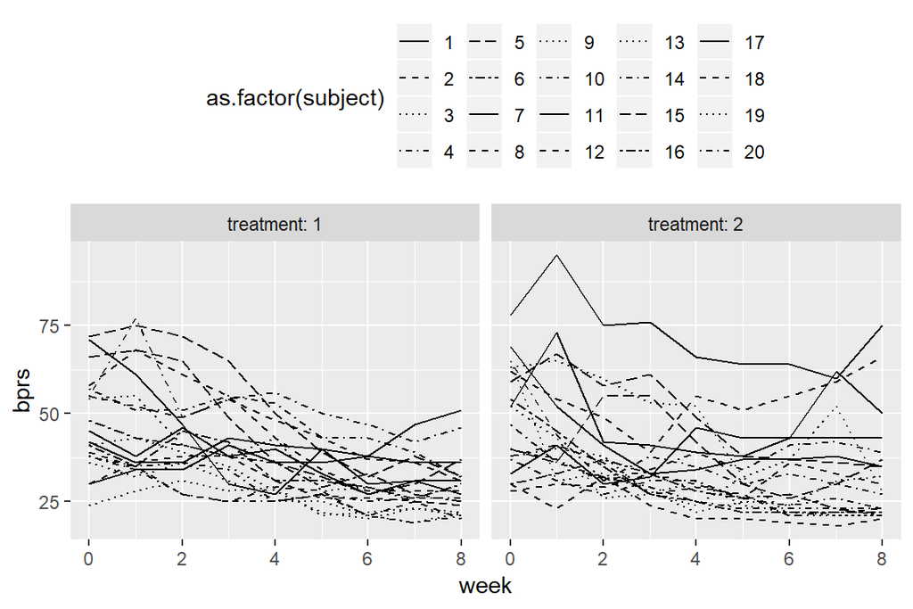

```r
ggplot(BPRSL, aes(x = week, y = bprs,linetype =as.factor(subject))) +
  geom_line() +scale_linetype_manual(values = rep(1:10, times = 4)) + facet_grid(.~treatment,labeller =label_both) + theme(legend.position = "top") + scale_y_continuous(limits = c(min(BPRSL$bprs),max(BPRSL$bprs)))
```

This is a plot showing the individuals bprs scoresthroughout the study (8weeks). We can see how they change, and how the two treatment groups differ from each other. The bprs scores seem to be declining in most cases, indicating that the treatments are working. There are, however also some individuals where the scores have risen during the treatment weeks. Also, from the plot it seems like the bprs scores from the treatment 1 group is convering in the end. This is quite interesting.

Next I’mgoing to fit a multiple linear regression model with bprs as response variable and week and treatment as explanatory variables

```r
# create a regression model bprs_reg
bprs_reg <- lm(bprs ~ week + treatment, data = BPRSL)

# print out a summary of the model
summary(bprs_reg)
```

```
##
## Call:
## lm(formula = bprs ~ week + treatment, data = BPRSL)
##
## Residuals:
##     Min      1Q  Median      3Q     Max
## -22.454  -8.965  -3.196   7.002  50.244
##
## Coefficients:
##             Estimate Std. Error t value Pr(>|t|)
## (Intercept)  46.4539     1.3670  33.982   <2e-16 ***
## week         -2.2704     0.2524  -8.995   <2e-16 ***
## treatment2    0.5722     1.3034   0.439    0.661
## ---
## Signif. codes:  0 '***' 0.001 '**' 0.01 '*' 0.05 '.' 0.1 ' ' 1
##
## Residual standard error: 12.37 on 357 degrees of freedom
## Multiple R-squared:  0.1851, Adjusted R-squared:  0.1806
## F-statistic: 40.55 on 2 and 357 DF,  p-value: < 2.2e-16
```

###### Random Intercept and Random Slope Models

Now we’re going to move on to more appropriate graphics and models. First we’re going to fit a random intercept model for the explanatory variables week and treatment. This allows for the linear regression for each subject to differ in intercept from the other subjects.

```r
library(lme4)
# Create a random intercept model
bprs_ref <- lmer(bprs ~ week + treatment + (1 | subject), data = BPRSL, REML = FALSE)

# Print the summary of the model
summary(bprs_ref)
```

```
## Linear mixed model fit by maximum likelihood  ['lmerMod']
## Formula: bprs ~ week + treatment + (1 | subject)
##    Data: BPRSL
##
##      AIC      BIC   logLik deviance df.resid
##   2748.7   2768.1  -1369.4   2738.7      355
##
## Scaled residuals:
##     Min      1Q  Median      3Q     Max
## -3.0481 -0.6749 -0.1361  0.4813  3.4855
##
## Random effects:
##  Groups   Name        Variance Std.Dev.
##  subject  (Intercept)  47.41    6.885
##  Residual             104.21   10.208
## Number of obs: 360, groups:  subject, 20
##
## Fixed effects:
##             Estimate Std. Error t value
## (Intercept)  46.4539     1.9090  24.334
## week         -2.2704     0.2084 -10.896
## treatment2    0.5722     1.0761   0.532
##
## Correlation of Fixed Effects:
##            (Intr) week
## week       -0.437
## treatment2 -0.282  0.000
```

The standard deviation of the subject is 6.885,which can be seen from the summary.

Next,I’m going to fit the random intercept and random slope model onthe bprs data. This allows the linearregression fits fro each individualto differ in intercept and also in slope. This way we can account for individual subjects’ bprs scores, and also how the change happens over time.

```r
# create a random intercept and random slope model
bprs_ref1 <- lmer(bprs ~ week + treatment + (week | subject), data = BPRSL, REML = FALSE)

# print a summary of the model
summary(bprs_ref1)
```

```
## Linear mixed model fit by maximum likelihood  ['lmerMod']
## Formula: bprs ~ week + treatment + (week | subject)
##    Data: BPRSL
##
##      AIC      BIC   logLik deviance df.resid
##   2745.4   2772.6  -1365.7   2731.4      353
##
## Scaled residuals:
##     Min      1Q  Median      3Q     Max
## -2.8919 -0.6194 -0.0691  0.5531  3.7976
##
## Random effects:
##  Groups   Name        Variance Std.Dev. Corr
##  subject  (Intercept) 64.8202  8.0511
##           week         0.9608  0.9802   -0.51
##  Residual             97.4307  9.8707
## Number of obs: 360, groups:  subject, 20
##
## Fixed effects:
##             Estimate Std. Error t value
## (Intercept)  46.4539     2.1052  22.066
## week         -2.2704     0.2977  -7.626
## treatment2    0.5722     1.0405   0.550
##
## Correlation of Fixed Effects:
##            (Intr) week
## week       -0.582
## treatment2 -0.247  0.000
```

```r
# perform an ANOVA test on the two models
anova(bprs_ref1,bprs_ref)
```

```
## Data: BPRSL
## Models:
## bprs_ref: bprs ~ week + treatment + (1 | subject)
## bprs_ref1: bprs ~ week + treatment + (week | subject)
##           Df    AIC    BIC  logLik deviance  Chisq Chi Df Pr(>Chisq)
## bprs_ref   5 2748.7 2768.1 -1369.4   2738.7
## bprs_ref1  7 2745.4 2772.6 -1365.7   2731.4 7.2721      2    0.02636 *
## ---
## Signif. codes:  0 '***' 0.001 '**' 0.01 '*' 0.05 '.' 0.1 ' ' 1
```

For the final part I’m going to fit a random intercept and slope model on the data. This allows for a group x time interaction. I’m also going to perform a ANOVA-test on the data,to tell how well the model fits.

```r
# create a random intercept and random slope model with the interaction
bprs_ref2 <- lmer(bprs ~ week * treatment + (week | subject), data = BPRSL, REML = FALSE)

# print a summary of the model
summary(bprs_ref2)
```

```
## Linear mixed model fit by maximum likelihood  ['lmerMod']
## Formula: bprs ~ week * treatment + (week | subject)
##    Data: BPRSL
##
##      AIC      BIC   logLik deviance df.resid
##   2744.3   2775.4  -1364.1   2728.3      352
##
## Scaled residuals:
##     Min      1Q  Median      3Q     Max
## -3.0512 -0.6271 -0.0767  0.5288  3.9260
##
## Random effects:
##  Groups   Name        Variance Std.Dev. Corr
##  subject  (Intercept) 65.0016  8.0624
##           week         0.9688  0.9843   -0.51
##  Residual             96.4699  9.8219
## Number of obs: 360, groups:  subject, 20
##
## Fixed effects:
##                 Estimate Std. Error t value
## (Intercept)      47.8856     2.2522  21.262
## week             -2.6283     0.3589  -7.323
## treatment2       -2.2911     1.9090  -1.200
## week:treatment2   0.7158     0.4010   1.785
##
## Correlation of Fixed Effects:
##             (Intr) week   trtmn2
## week        -0.650
## treatment2  -0.424  0.469
## wek:trtmnt2  0.356 -0.559 -0.840
```

```r
# perform an ANOVA test on the two models
anova(bprs_ref2, bprs_ref1)
```

```
## Data: BPRSL
## Models:
## bprs_ref1: bprs ~ week + treatment + (week | subject)
## bprs_ref2: bprs ~ week * treatment + (week | subject)
##           Df    AIC    BIC  logLik deviance  Chisq Chi Df Pr(>Chisq)
## bprs_ref1  7 2745.4 2772.6 -1365.7   2731.4
## bprs_ref2  8 2744.3 2775.4 -1364.1   2728.3 3.1712      1    0.07495 .
## ---
## Signif. codes:  0 '***' 0.001 '**' 0.01 '*' 0.05 '.' 0.1 ' ' 1
```

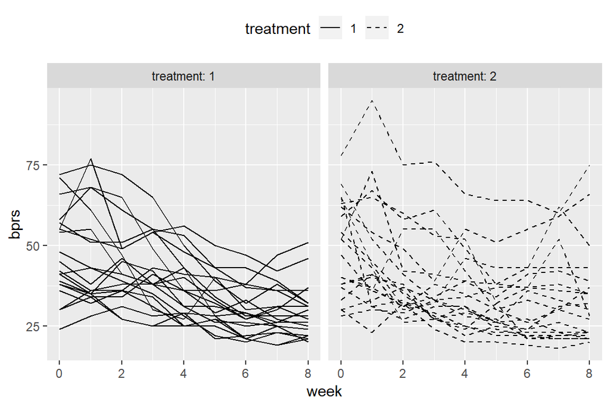

```r
# draw the plot of BPRSL
ggplot(BPRSL, aes(x = week, y = bprs, group = subject)) +
  geom_line(aes(linetype = treatment)) +
  scale_linetype_manual(values =rep(1:10, times =4)) +
  scale_y_continuous(name = "bprs", limits = c(min(BPRSL$bprs), max(BPRSL$bprs))) +facet_grid(.~treatment, labeller = label_both) +
  theme(legend.position = "top")
```

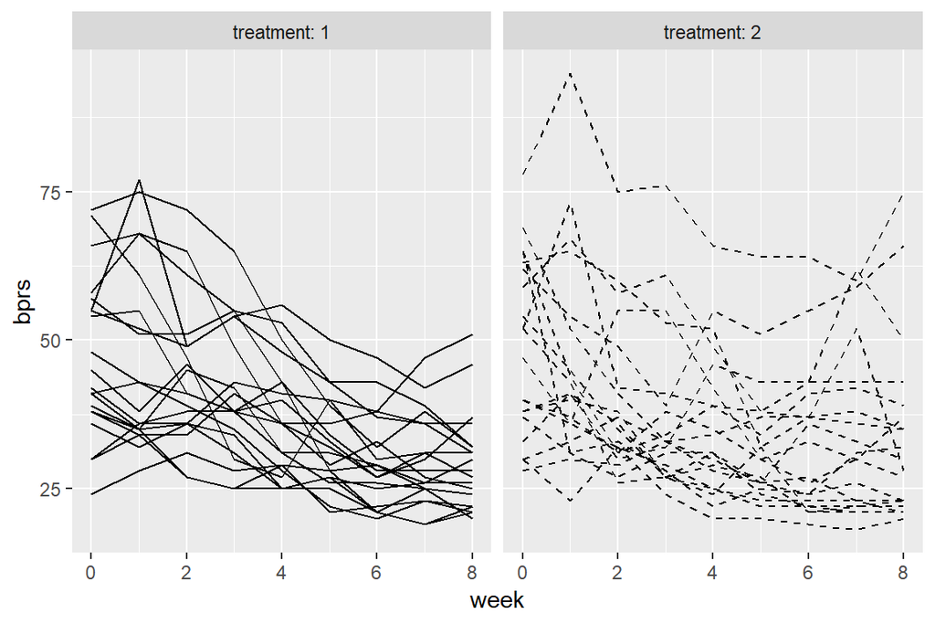

```r
# Create a vector of the fitted values
Fitted <- fitted(bprs_ref2)

# Create a new column fitted to BPRSL
BPRSL <- BPRSL %>% mutate(Fitted)


# draw the plot of BPRSL with the Fitted values
ggplot(BPRSL, aes(x = week, y = bprs, group = subject)) +
  geom_line(aes(linetype = treatment)) +scale_linetype_manual(values =rep(1:10, times =4)) +
  scale_y_continuous(name = "bprs", limits = c(min(BPRSL$bprs), max(BPRSL$bprs))) +facet_grid(.~treatment, labeller = label_both) +
  theme(legend.position = "none")
```

In the second plotI tried to create a vector of fitted values. Then i tried to add the vector as a column in BPRSL and then i tried to create a new plot. This did, however, not work at all, and Idon’t see what I did wrong.. Anyhow, without a proper graph it’s hard to do a good interpretation on it.